Saltar al contenido principal

dgtrabada

- .rst

# Cuestionario RAID

Cuando se pregunta *¿cuántos discos se pueden romper como máximo?* se refiere al mejor de los casos (con suerte en la posición); *sin importar la posición* se refiere a los que están garantizados, se rompan los que se rompan.

## RAID (I)

Tenemos 6 discos duros de 1 TB.

1. ¿A qué RAID corresponde el siguiente esquema?

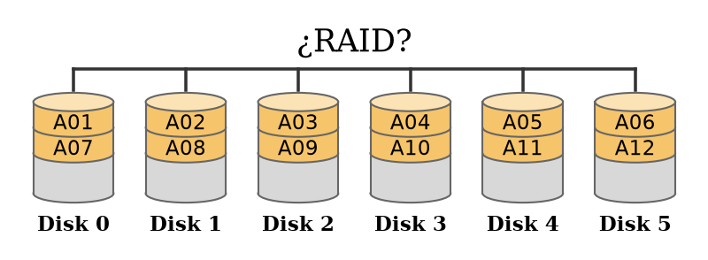

1. RAID:

2. ¿Cuál es la capacidad final en TB?

3. ¿Cuántos discos se pueden romper como máximo sin importar la posición en la que se rompan?

2. ¿A qué RAID corresponde el siguiente esquema?

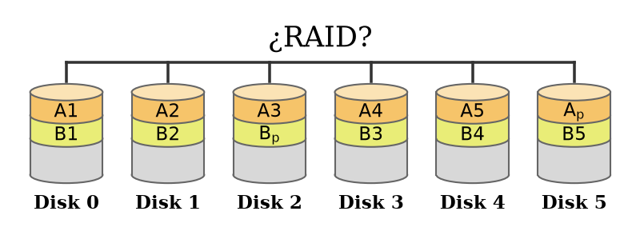

1. RAID:

2. ¿Cuál es la capacidad final en TB?

3. ¿Cuántos discos se pueden romper como máximo sin importar la posición en la que se rompan?

3. ¿A qué RAID corresponde el siguiente esquema?

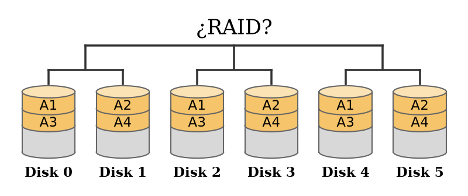

1. RAID:

2. ¿Cuál es la capacidad final en TB?

3. ¿Cuántos discos se pueden romper como máximo?

4. ¿Cuántos discos se pueden romper como máximo sin importar la posición en la que se rompan?

4. ¿A qué RAID corresponde el siguiente esquema?

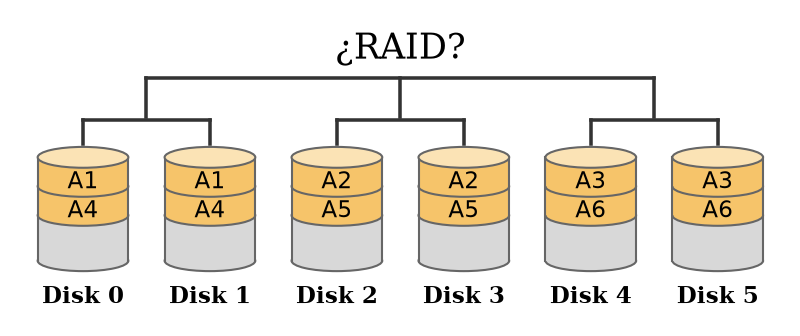

1. RAID:

2. ¿Cuál es la capacidad final en TB?

3. ¿Cuántos discos se pueden romper como máximo?

4. ¿Cuántos discos se pueden romper como máximo sin importar la posición en la que se rompan?

5. ¿A qué RAID corresponde el siguiente esquema?

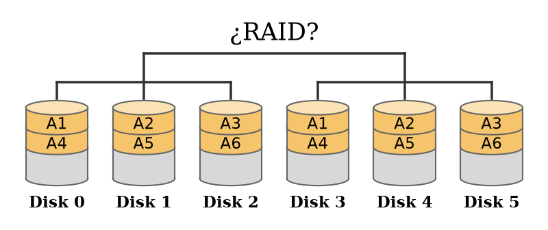

1. RAID:

2. ¿Cuál es la capacidad final en TB?

3. ¿Cuántos discos se pueden romper como máximo?

4. ¿Cuántos discos se pueden romper como máximo sin importar la posición en la que se rompan?

6. ¿A qué RAID corresponde el siguiente esquema?

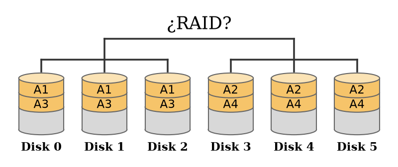

1. RAID:

2. ¿Cuál es la capacidad final en TB?

3. ¿Cuántos discos se pueden romper como máximo?

4. ¿Cuántos discos se pueden romper como máximo sin importar la posición en la que se rompan?

## RAID (II)

Tenemos 8 discos duros de 1 TB.

1. ¿A qué RAID corresponde el siguiente esquema?

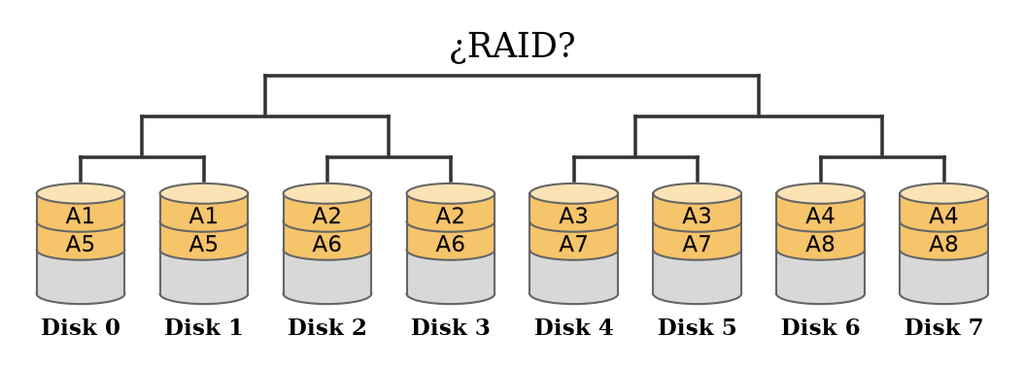

1. RAID:

2. ¿Cuál es la capacidad final en TB?

3. ¿Cuántos discos se pueden romper como máximo?

4. ¿Cuántos discos se pueden romper como máximo sin importar la posición en la que se rompan?

2. ¿A qué RAID corresponde el siguiente esquema?

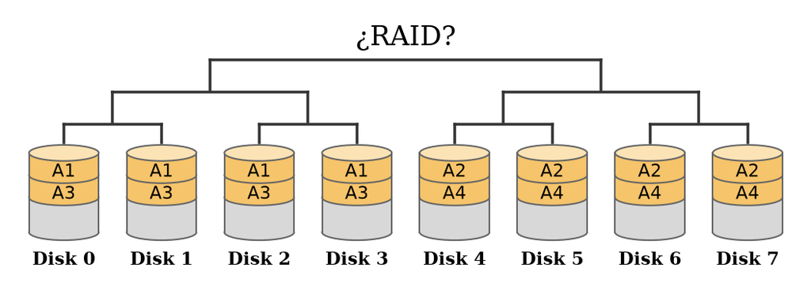

1. RAID:

2. ¿Cuál es la capacidad final en TB?

3. ¿Cuántos discos se pueden romper como máximo?

4. ¿Cuántos discos se pueden romper como máximo sin importar la posición en la que se rompan?

3. ¿A qué RAID corresponde el siguiente esquema?

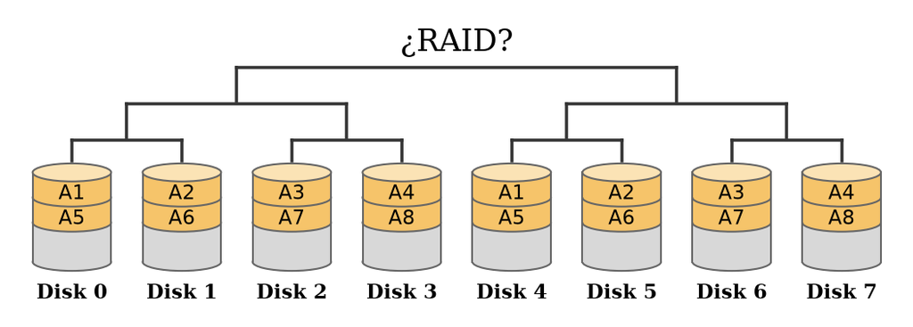

1. RAID:

2. ¿Cuál es la capacidad final en TB?

3. ¿Cuántos discos se pueden romper como máximo?

4. ¿Cuántos discos se pueden romper como máximo sin importar la posición en la que se rompan?

4. ¿A qué RAID corresponde el siguiente esquema?

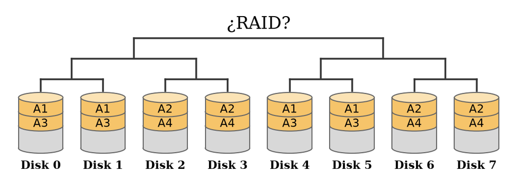

1. RAID:

2. ¿Cuál es la capacidad final en TB?

3. ¿Cuántos discos se pueden romper como máximo?

4. ¿Cuántos discos se pueden romper como máximo sin importar la posición en la que se rompan?

## RAID (III)

1. Tenemos 8 discos duros de 2 TB en RAID 0:

1. ¿Cuál es la capacidad final en TB?

2. ¿Cuántos discos se pueden romper como máximo?

3. ¿Cuántos discos se pueden romper como máximo sin importar la posición en la que se rompan?

2. Tenemos 4 discos duros de 2 TB en RAID 1:

1. ¿Cuál es la capacidad final en TB?

2. ¿Cuántos discos se pueden romper como máximo?

3. ¿Cuántos discos se pueden romper como máximo sin importar la posición en la que se rompan?

3. Tenemos 8 discos duros de 2 TB en RAID 5:

1. ¿Cuál es la capacidad final en TB?

2. ¿Cuántos discos se pueden romper como máximo?

3. ¿Cuántos discos se pueden romper como máximo sin importar la posición en la que se rompan?

4. Tenemos 6 discos duros de 2 TB agrupados de dos en dos en RAID 01:

1. ¿Cuál es la capacidad final en TB?

2. ¿Cuántos discos se pueden romper como máximo?

3. ¿Cuántos discos se pueden romper como máximo sin importar la posición en la que se rompan?

5. Tenemos 6 discos duros de 2 TB agrupados de dos en dos en RAID 10:

1. ¿Cuál es la capacidad final en TB?

2. ¿Cuántos discos se pueden romper como máximo?

3. ¿Cuántos discos se pueden romper como máximo sin importar la posición en la que se rompan?

6. Tenemos 9 discos duros de 2 TB agrupados de tres en tres en RAID 50:

1. ¿Cuál es la capacidad final en TB?

2. ¿Cuántos discos se pueden romper como máximo?

3. ¿Cuántos discos se pueden romper como máximo sin importar la posición en la que se rompan?

7. Tenemos 12 discos duros de 2 TB agrupados de cuatro en cuatro en RAID 51:

1. ¿Cuál es la capacidad final en TB?

2. ¿Cuántos discos se pueden romper como máximo?

3. ¿Cuántos discos se pueden romper como máximo sin importar la posición en la que se rompan?

8. Tenemos 10 discos duros de 4 TB agrupados de cinco en cinco en RAID 60:

1. ¿Cuál es la capacidad final en TB?

2. ¿Cuántos discos se pueden romper como máximo?

3. ¿Cuántos discos se pueden romper como máximo sin importar la posición en la que se rompan?

## RAID (IV)

1. Tenemos 8 discos duros de 2 TB en RAID 01 agrupados de 2 en 2:

1. ¿Cuántos TB tenemos?

2. ¿Cuántos discos se pueden romper como máximo?

3. ¿Cuántos discos se pueden romper como máximo sin importar la posición en la que se rompan?

2. Tenemos 8 discos duros de 2 TB en RAID 01 agrupados de 4 en 4:

1. ¿Cuántos TB tenemos?

2. ¿Cuántos discos se pueden romper como máximo?

3. ¿Cuántos discos se pueden romper como máximo sin importar la posición en la que se rompan?

3. Tenemos 8 discos duros de 2 TB en RAID 10 agrupados de 2 en 2:

1. ¿Cuántos TB tenemos?

2. ¿Cuántos discos se pueden romper como máximo?

3. ¿Cuántos discos se pueden romper como máximo sin importar la posición en la que se rompan?

4. Tenemos 8 discos duros de 2 TB en RAID 10 agrupados de 4 en 4:

1. ¿Cuántos TB tenemos?

2. ¿Cuántos discos se pueden romper como máximo?

3. ¿Cuántos discos se pueden romper como máximo sin importar la posición en la que se rompan?

5. Tenemos 8 discos duros de 2 TB en RAID 50 agrupados de 4 en 4:

1. ¿Cuántos TB tenemos?

2. ¿Cuántos discos se pueden romper como máximo?

3. ¿Cuántos discos se pueden romper como máximo sin importar la posición en la que se rompan?

6. Tenemos 9 discos duros de 2 TB en RAID 50 agrupados de 3 en 3:

1. ¿Cuántos TB tenemos?

2. ¿Cuántos discos se pueden romper como máximo?

3. ¿Cuántos discos se pueden romper como máximo sin importar la posición en la que se rompan?

7. Tenemos 8 discos duros de 2 TB en RAID 100 agrupados de 2 en 2:

1. ¿Cuántos TB tenemos?

2. ¿Cuántos discos se pueden romper como máximo?

3. ¿Cuántos discos se pueden romper como máximo sin importar la posición en la que se rompan?

8. Tenemos 8 discos duros de 2 TB en RAID 110 agrupados de 2 en 2:

1. ¿Cuántos TB tenemos?

2. ¿Cuántos discos se pueden romper como máximo?

3. ¿Cuántos discos se pueden romper como máximo sin importar la posición en la que se rompan?

9. Tenemos 12 discos duros de 2 TB en RAID 60 agrupados de 4 en 4:

1. ¿Cuántos TB tenemos?

2. ¿Cuántos discos se pueden romper como máximo?

3. ¿Cuántos discos se pueden romper como máximo sin importar la posición en la que se rompan?

Contenido